# NBA Reproducible Data analysis Project

David Mawa

04/05/2021

## Packages:

These are the packages that will be used in this project.

```r
library(tidyverse)
library(broom)
library(ggcorrplot)
```

## Introduction:

The National Basketball Association (NBA) is a professional basketball league in North America comprising 30 franchises, of which 29 are located in the United States and one in Canada (Toronto Raptors). The league was founded in 1946, then named the Basketball Association of America (BAA). In 1949, the BAA merged with the rival National Basketball League (NBL) to form the National Basketball Association. Today the NBA as a whole generates around eight billion U.S. dollars in revenue per season, an average per team of around 264 million U.S. dollars in a season(statista.com). Organized basketball is a game played by five players per team. Historically, these players have been assigned to positions defined by the role they play on the court. These positions are; the point guard, the shooting guard, the small forward, the power forward and the center(wikipedia.org). The previous season Chicago Bulls was placed 27th out of 30 based on win-loss record. The purpose of this project is to analysis the given NBA datasets to find the top five starting players (one from each position) that the Chicago Bulls team can recruit but also maintaining to fill a full team roster. The Chicago Bull’s budget for player contracts for the following season is $118 million. The analysis will help the Chicago Bulls find quality players for the next season with low salaries and help improve the team. The matric I will use to evaluate the players will be based on points to minute played ratio (pmp). Calculated as pmp = PTS (points)/MP (minute played).

## Reading the raw datasets:

Uploading the datasets in R.

```r
player_salaries <- read_csv("2018-19_nba_player-salaries.csv")
player_stats <- read_csv("2018-19_nba_player-statistics.csv")
team_stats_1 <- read_csv("2018-19_nba_team-statistics_1.csv")
team_stats_2 <- read_csv("2018-19_nba_team-statistics_2.csv")
team_payroll <- read_csv("2019-20_nba_team-payroll.csv")
```

## Datasets description:

This is the brief description of the datasets that will be used in analysis.

2018-19_nba_player-statistics.csv. This data file provides total statistics for individual NBA players during the 2018-19 season. Has 708 observations and 29 variables. The variables consist:

player_name : Player Name Pos : (PG = point guard, SG = shooting guard, SF = small forward, PF = power forward, C = center) Age : Age of Player at the start of February 1st of that season. Tm : Team G : Games GS : Games Started MP : Minutes Played FG : Field Goals FGA : Field Goal Attempts FG% : Field Goal Percentage 3P : 3-Point Field Goals 3PA : 3-Point Field Goal Attempts 3P% : FG% on 3-Pt FGAs 2P : 2-Point Field Goals 2PA : 2-point Field Goal Attempts 2P% : FG% on 2-Pt FGAs eFG% : Effective Field Goal Percentage FT : Free Throws FTA : Free Throw Attempts FT% : Free Throw Percentage ORB : Offensive Rebounds DRB : Defensive Rebounds TRB : Total Rebounds AST : Assists STL : Steals BLK : Blocks TOV : Turnovers PF : Personal Fouls PTS : Points

2018-19_nba_player-salaries.csv. This data file contains the salary for individual players during the 2018-19 NBA season. Has 576 observations and 3 variables.The variables consist:

player_id : unique player identification number player_name : player name salary : year salary in $USD

## Data cleaning.

Looking at the datasets.

```r
head(player_salaries)
```

```
## # A tibble: 6 x 3
##   player_id player_name    salary
##       <dbl> <chr>           <dbl>
## 1         1 Alex Abrines  3667645
## 2         2 Quincy Acy     213948
## 3         3 Steven Adams 24157304
## 4         4 Jaylen Adams   236854
## 5         5 Bam Adebayo   2955840
## 6         6 Deng Adel       77250
```

```r
tail(player_salaries)
```

```
## # A tibble: 6 x 3
##   player_id player_name    salary
##       <dbl> <chr>           <dbl>
## 1       571 Rade Zagorac  1378242
## 2       572 Cody Zeller  13528090
## 3       573 Tyler Zeller   213948
## 4       574 Ante Zizic    1952760
## 5       575 Ivica Zubac   1544951
## 6       576 Nene          3651480
```

```r
dim(player_salaries)
```

```
## [1] 576   3
```

```r
head(player_stats)
```

```
## # A tibble: 6 x 29
##   player_name  Pos     Age Tm        G    GS    MP    FG   FGA `FG%`  `3P` `3PA`
##   <chr>        <chr> <dbl> <chr> <dbl> <dbl> <dbl> <dbl> <dbl> <dbl> <dbl> <dbl>
## 1 Alex Abrines SG       25 OKC      31     2   588    56   157 0.357    41   127
## 2 Quincy Acy   PF       28 PHO      10     0   123     4    18 0.222     2    15
## 3 Jaylen Adams PG       22 ATL      34     1   428    38   110 0.345    25    74
## 4 Steven Adams C        25 OKC      80    80  2669   481   809 0.595     0     2
## 5 Bam Adebayo  C        21 MIA      82    28  1913   280   486 0.576     3    15
## 6 Deng Adel    SF       21 CLE      19     3   194    11    36 0.306     6    23
## # … with 17 more variables: 3P% <dbl>, 2P <dbl>, 2PA <dbl>, 2P% <dbl>,
## #   eFG% <dbl>, FT <dbl>, FTA <dbl>, FT% <dbl>, ORB <dbl>, DRB <dbl>,
## #   TRB <dbl>, AST <dbl>, STL <dbl>, BLK <dbl>, TOV <dbl>, PF <dbl>, PTS <dbl>
```

```r
tail(player_stats)
```

```
## # A tibble: 6 x 29
##   player_name Pos     Age Tm        G    GS    MP    FG   FGA `FG%`  `3P` `3PA`
##   <chr>       <chr> <dbl> <chr> <dbl> <dbl> <dbl> <dbl> <dbl> <dbl> <dbl> <dbl>
## 1 Ivica Zubac C        21 LAL      33    12   516   112   193 0.580     0     0
## 2 Ivica Zubac C        21 TOT      59    37  1040   212   379 0.559     0     0
## 3 Dario Saric PF       24 PHI      13    13   396    48   132 0.364    21    70
## 4 Dario Saric PF       24 MIN      68    28  1627   256   564 0.454    97   253
## 5 Dario Saric PF       24 TOT      81    41  2023   304   696 0.437   118   323
## 6 Ante Zizic  C        22 CLE      59    25  1082   183   331 0.553     0     0
## # … with 17 more variables: 3P% <dbl>, 2P <dbl>, 2PA <dbl>, 2P% <dbl>,
## #   eFG% <dbl>, FT <dbl>, FTA <dbl>, FT% <dbl>, ORB <dbl>, DRB <dbl>,
## #   TRB <dbl>, AST <dbl>, STL <dbl>, BLK <dbl>, TOV <dbl>, PF <dbl>, PTS <dbl>
```

```r
dim(player_stats)
```

```
## [1] 708  29
```

Missing values handling. The player salaries data has no missing values.

The player statistics data has 117 missing values.

```r
player_salaries %>% summarise(sum(is.na(.)))
```

```
## # A tibble: 1 x 1
##   `sum(is.na(.))`
##             <int>
## 1               0
```

```r
player_stats %>% summarise(sum(is.na(.)))
```

```
## # A tibble: 1 x 1
##   `sum(is.na(.))`
##             <int>
## 1             117
```

Columns that contain the missing values from the player statistics data.

The missing values are from players who played less games. Therefore will drop them.

```r
colnames(is.na(player_stats))
```

```
##  [1] "player_name" "Pos"         "Age"         "Tm"          "G"
##  [6] "GS"          "MP"          "FG"          "FGA"         "FG%"
## [11] "3P"          "3PA"         "3P%"         "2P"          "2PA"
## [16] "2P%"         "eFG%"        "FT"          "FTA"         "FT%"
## [21] "ORB"         "DRB"         "TRB"         "AST"         "STL"
## [26] "BLK"         "TOV"         "PF"          "PTS"
```

```r
colSums(is.na(player_stats)) %>% as.data.frame()
```

```
##              .
## player_name  0
## Pos          0
## Age          0
## Tm           0
## G            0
## GS           0
## MP           0
## FG           0
## FGA          0
## FG%          6
## 3P           0
## 3PA          0
## 3P%         47
## 2P           0
## 2PA          0
## 2P%         15
## eFG%         6
## FT           0
## FTA          0
## FT%         43
## ORB          0
## DRB          0
## TRB          0
## AST          0
## STL          0
## BLK          0
## TOV          0
## PF           0
## PTS          0
```

Dropping missing values.

```r
player_stats_clean <- player_stats %>% drop_na()
player_stats_clean
```

```
## # A tibble: 629 x 29
##    player_name Pos     Age Tm        G    GS    MP    FG   FGA `FG%`  `3P` `3PA`
##    <chr>       <chr> <dbl> <chr> <dbl> <dbl> <dbl> <dbl> <dbl> <dbl> <dbl> <dbl>
##  1 Alex Abrin… SG       25 OKC      31     2   588    56   157 0.357    41   127
##  2 Quincy Acy  PF       28 PHO      10     0   123     4    18 0.222     2    15
##  3 Jaylen Ada… PG       22 ATL      34     1   428    38   110 0.345    25    74
##  4 Steven Ada… C        25 OKC      80    80  2669   481   809 0.595     0     2
##  5 Bam Adebayo C        21 MIA      82    28  1913   280   486 0.576     3    15
##  6 Deng Adel   SF       21 CLE      19     3   194    11    36 0.306     6    23
##  7 DeVaughn A… SG       25 DEN       7     0    22     3    10 0.3       0     4
##  8 LaMarcus A… C        33 SAS      81    81  2687   684  1319 0.519    10    42
##  9 Rawle Alki… SG       21 CHI      10     1   120    13    39 0.333     3    12
## 10 Grayson Al… SG       23 UTA      38     2   416    67   178 0.376    32    99
## # … with 619 more rows, and 17 more variables: 3P% <dbl>, 2P <dbl>, 2PA <dbl>,
## #   2P% <dbl>, eFG% <dbl>, FT <dbl>, FTA <dbl>, FT% <dbl>, ORB <dbl>,
## #   DRB <dbl>, TRB <dbl>, AST <dbl>, STL <dbl>, BLK <dbl>, TOV <dbl>, PF <dbl>,
## #   PTS <dbl>
```

Merging player salaries data and player statistics clean data.

```r
player_data <- full_join(player_salaries, player_stats_clean, by = "player_name")
player_data
```

```
## # A tibble: 746 x 31
##    player_id player_name  salary Pos     Age Tm        G    GS    MP    FG   FGA
##        <dbl> <chr>         <dbl> <chr> <dbl> <chr> <dbl> <dbl> <dbl> <dbl> <dbl>
##  1         1 Alex Abrines 3.67e6 SG       25 OKC      31     2   588    56   157
##  2         2 Quincy Acy   2.14e5 PF       28 PHO      10     0   123     4    18
##  3         3 Steven Adams 2.42e7 C        25 OKC      80    80  2669   481   809
##  4         4 Jaylen Adams 2.37e5 PG       22 ATL      34     1   428    38   110
##  5         5 Bam Adebayo  2.96e6 C        21 MIA      82    28  1913   280   486
##  6         6 Deng Adel    7.72e4 SF       21 CLE      19     3   194    11    36
##  7         7 Alexis Ajin… 5.29e6 <NA>     NA <NA>     NA    NA    NA    NA    NA
##  8         8 DeVaughn Ak… 7.72e4 SG       25 DEN       7     0    22     3    10
##  9         9 Cole Aldrich 2.00e6 <NA>     NA <NA>     NA    NA    NA    NA    NA
## 10        10 LaMarcus Al… 2.23e7 C        33 SAS      81    81  2687   684  1319
## # … with 736 more rows, and 20 more variables: FG% <dbl>, 3P <dbl>, 3PA <dbl>,
## #   3P% <dbl>, 2P <dbl>, 2PA <dbl>, 2P% <dbl>, eFG% <dbl>, FT <dbl>, FTA <dbl>,
## #   FT% <dbl>, ORB <dbl>, DRB <dbl>, TRB <dbl>, AST <dbl>, STL <dbl>,
## #   BLK <dbl>, TOV <dbl>, PF <dbl>, PTS <dbl>
```

Duplicates handling. There are players that are repeated due to season trading.

```r
unique(player_data$player_name[duplicated(player_data$player_id)]) %>% as.data.frame()
```

```
##                          .
## 1            Ryan Anderson
## 2             Trevor Ariza
## 3                Ron Baker
## 4          Harrison Barnes
## 5            Avery Bradley
## 6             Corey Brewer
## 7           Reggie Bullock
## 8               Trey Burke
## 9               Alec Burks
## 10            Jimmy Butler
## 11           Isaiah Canaan
## 12 Michael Carter-Williams
## 13          Tyson Chandler
## 14         Wilson Chandler
```

[output cut: 79 more lines]

```r
player_data <- player_data[!duplicated(player_data$player_id), ]
player_data
```

```
## # A tibble: 577 x 31
##    player_id player_name  salary Pos     Age Tm        G    GS    MP    FG   FGA
##        <dbl> <chr>         <dbl> <chr> <dbl> <chr> <dbl> <dbl> <dbl> <dbl> <dbl>
##  1         1 Alex Abrines 3.67e6 SG       25 OKC      31     2   588    56   157
##  2         2 Quincy Acy   2.14e5 PF       28 PHO      10     0   123     4    18
##  3         3 Steven Adams 2.42e7 C        25 OKC      80    80  2669   481   809
##  4         4 Jaylen Adams 2.37e5 PG       22 ATL      34     1   428    38   110
##  5         5 Bam Adebayo  2.96e6 C        21 MIA      82    28  1913   280   486
##  6         6 Deng Adel    7.72e4 SF       21 CLE      19     3   194    11    36
##  7         7 Alexis Ajin… 5.29e6 <NA>     NA <NA>     NA    NA    NA    NA    NA
##  8         8 DeVaughn Ak… 7.72e4 SG       25 DEN       7     0    22     3    10
##  9         9 Cole Aldrich 2.00e6 <NA>     NA <NA>     NA    NA    NA    NA    NA
## 10        10 LaMarcus Al… 2.23e7 C        33 SAS      81    81  2687   684  1319
## # … with 567 more rows, and 20 more variables: FG% <dbl>, 3P <dbl>, 3PA <dbl>,
## #   3P% <dbl>, 2P <dbl>, 2PA <dbl>, 2P% <dbl>, eFG% <dbl>, FT <dbl>, FTA <dbl>,
## #   FT% <dbl>, ORB <dbl>, DRB <dbl>, TRB <dbl>, AST <dbl>, STL <dbl>,
## #   BLK <dbl>, TOV <dbl>, PF <dbl>, PTS <dbl>
```

## Exploratory Data Analysis:

Missing values introduced after the two datasets are merged. The missing values are mostly from players with no defined position so will also drop them

```r
player_data_tidy <- player_data %>% drop_na()
player_data_tidy
```

```
## # A tibble: 459 x 31
##    player_id player_name  salary Pos     Age Tm        G    GS    MP    FG   FGA
##        <dbl> <chr>         <dbl> <chr> <dbl> <chr> <dbl> <dbl> <dbl> <dbl> <dbl>
##  1         1 Alex Abrines 3.67e6 SG       25 OKC      31     2   588    56   157
##  2         2 Quincy Acy   2.14e5 PF       28 PHO      10     0   123     4    18
##  3         3 Steven Adams 2.42e7 C        25 OKC      80    80  2669   481   809
##  4         4 Jaylen Adams 2.37e5 PG       22 ATL      34     1   428    38   110
##  5         5 Bam Adebayo  2.96e6 C        21 MIA      82    28  1913   280   486
##  6         6 Deng Adel    7.72e4 SF       21 CLE      19     3   194    11    36
##  7         8 DeVaughn Ak… 7.72e4 SG       25 DEN       7     0    22     3    10
##  8        10 LaMarcus Al… 2.23e7 C        33 SAS      81    81  2687   684  1319
##  9        11 Rawle Alkins 7.72e4 SG       21 CHI      10     1   120    13    39
## 10        12 Grayson All… 2.08e6 SG       23 UTA      38     2   416    67   178
## # … with 449 more rows, and 20 more variables: FG% <dbl>, 3P <dbl>, 3PA <dbl>,
## #   3P% <dbl>, 2P <dbl>, 2PA <dbl>, 2P% <dbl>, eFG% <dbl>, FT <dbl>, FTA <dbl>,
## #   FT% <dbl>, ORB <dbl>, DRB <dbl>, TRB <dbl>, AST <dbl>, STL <dbl>,
## #   BLK <dbl>, TOV <dbl>, PF <dbl>, PTS <dbl>
```

Salaries Distribution. From the salary distribution plot, the histogram is skewed to the right.

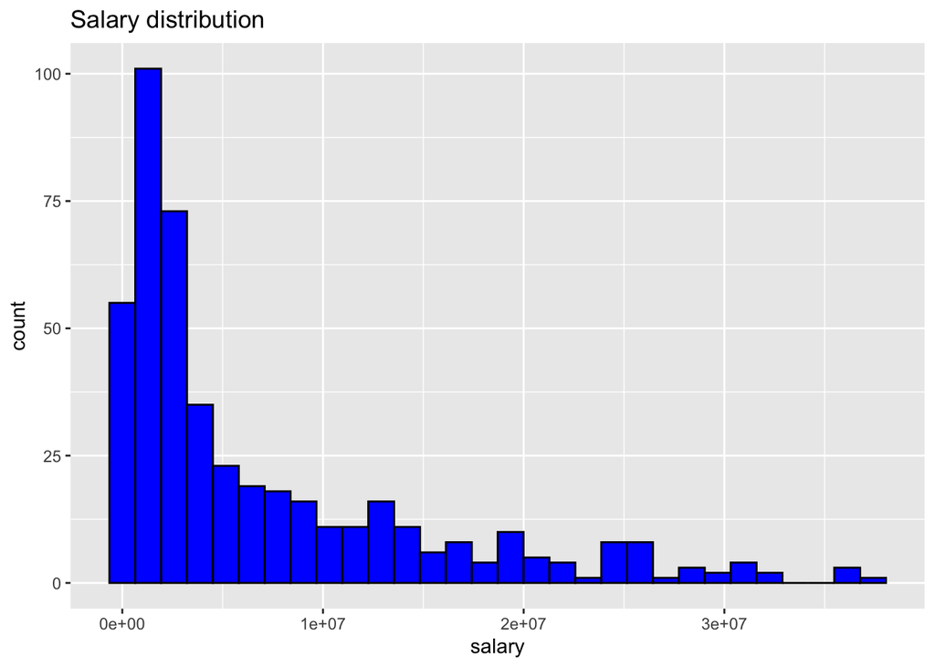

```r
ggplot(data = player_data_tidy, aes(x = salary)) +
  geom_histogram( color = "black", fill = "blue") + ggtitle("Salary distribution")
```

Salary summary. The median salary is $3258539 The mean salary is $6967454

```r
summary(player_data_tidy$salary)
```

```
##     Min.  1st Qu.   Median     Mean  3rd Qu.     Max.
##    47370  1528776  3258539  6967454 10275646 37457154
```

Questions to answer. Do players with higher game points have higher salaries? Do playing positions affects player’s salary?

Points vs Salary. Players that have higher points tend to have high salaries regardless of the position they player in.

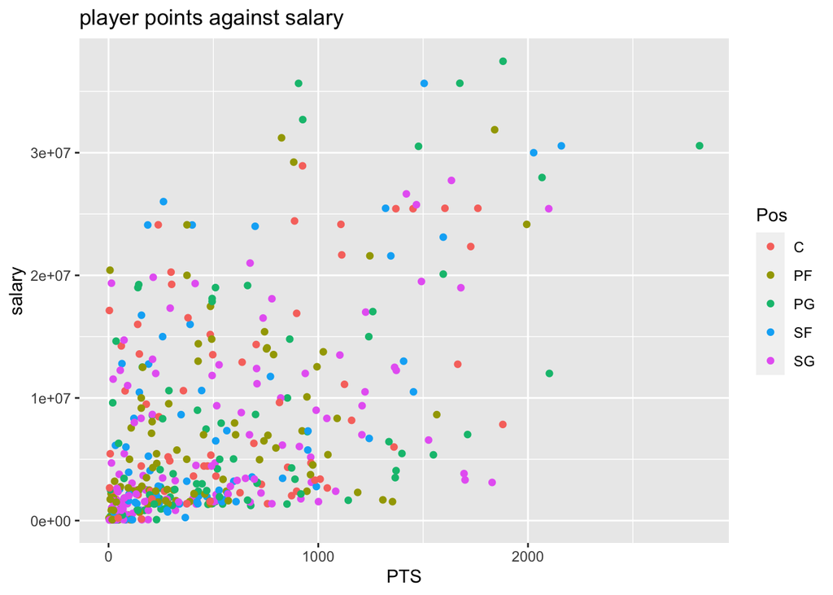

```r
ggplot(data = player_data_tidy, aes(x = PTS, y = salary, color = Pos)) +
  geom_point() + ggtitle("player points against salary")
```

Bar plot of positions. There are a high number of Shooting guard players in 2018-19 season compared to the other positions. Center position has the least number of players.

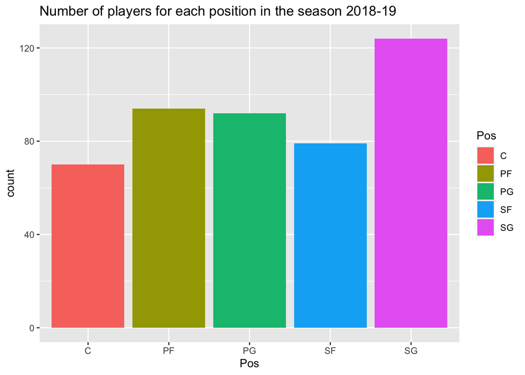

```r
ggplot(data = player_data_tidy, aes(x = Pos, fill = Pos)) + geom_bar() +
  ggtitle("Number of players for each position in the season 2018-19")
```

Games started by a player against points. This does not give a proper picture. Because there are players that started fewer games but they still have high points.

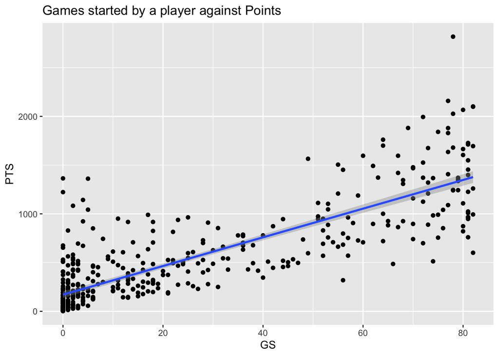

```r
ggplot(data = player_data_tidy, aes(x = GS, y = PTS)) + geom_point() +
  ggtitle("Games started by a player against Points") + geom_smooth(method = lm)
```

Minutes played. Players that played more minutes have high points.

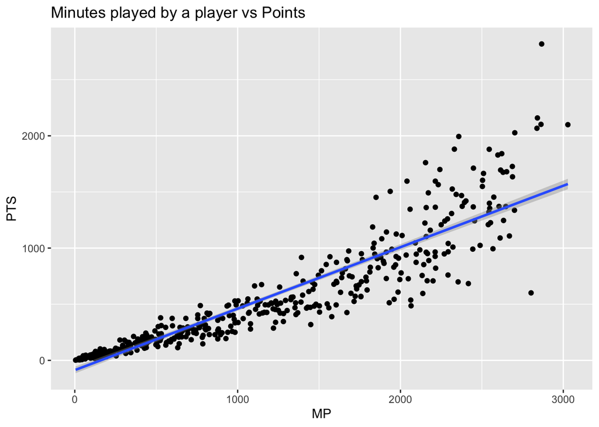

```r
ggplot(data = player_data_tidy, aes(x = MP, y = PTS)) + geom_point() +
  ggtitle("Minutes played by a player vs Points") +geom_smooth(method = lm)
```

Variable correlation. Salary is correlated with the other variables but not highly.

Points are highly correlated with Turnovers,Steals,Free Throw Attempts, Defensive Rebounds Free Throws,2-point Field Goal Attempts,2-Point Field Goals,3-Point Field Goal Attempts, 3-Point Field Goals,Field Goals,minutes Played,Games Started,Total Rebounds.

Player’s Age is correlated with salary. High correlation among some of the variables exist as well.

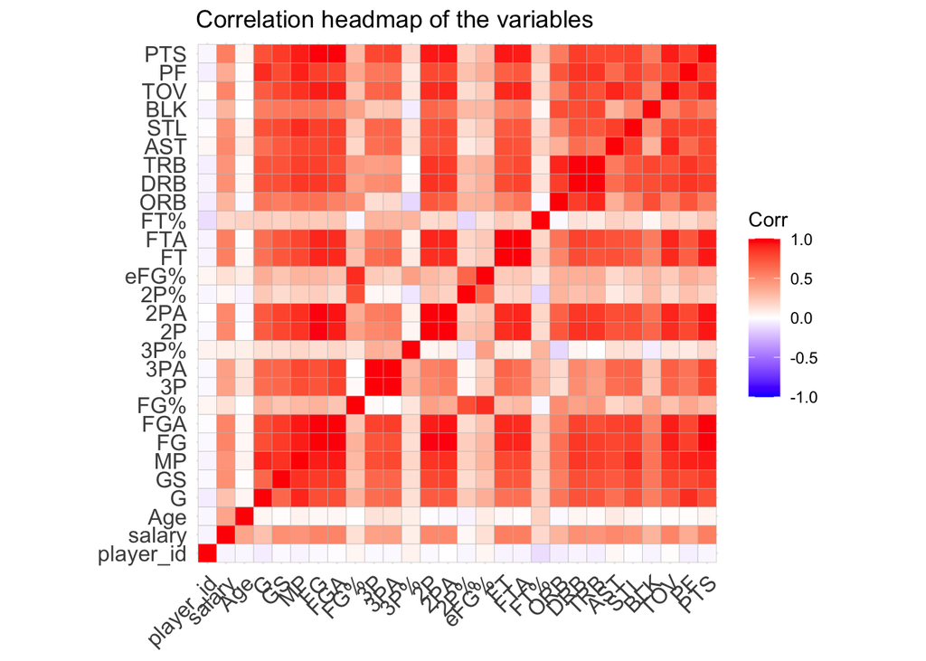

```r
cor_data <- player_data_tidy %>% select(-c(player_name, Pos, Tm))

ggcorrplot(cor(cor_data)) +ggtitle("Correlation headmap of the variables")
```

Features extraction. Extracting the variables to be used for the modeling

```r
model_data <- player_data_tidy %>%
  select(c(player_name,salary,Pos,Age,Tm,G,GS,MP,FG,FGA,"3P","3PA","2P","2PA",FT,FTA,DRB,TRB,TOV,PTS))
model_data
```

```
## # A tibble: 459 x 20
##    player_name      salary Pos     Age Tm        G    GS    MP    FG   FGA  `3P`
##    <chr>             <dbl> <chr> <dbl> <chr> <dbl> <dbl> <dbl> <dbl> <dbl> <dbl>
##  1 Alex Abrines     3.67e6 SG       25 OKC      31     2   588    56   157    41
##  2 Quincy Acy       2.14e5 PF       28 PHO      10     0   123     4    18     2
##  3 Steven Adams     2.42e7 C        25 OKC      80    80  2669   481   809     0
##  4 Jaylen Adams     2.37e5 PG       22 ATL      34     1   428    38   110    25
##  5 Bam Adebayo      2.96e6 C        21 MIA      82    28  1913   280   486     3
##  6 Deng Adel        7.72e4 SF       21 CLE      19     3   194    11    36     6
##  7 DeVaughn Akoon-… 7.72e4 SG       25 DEN       7     0    22     3    10     0
##  8 LaMarcus Aldrid… 2.23e7 C        33 SAS      81    81  2687   684  1319    10
##  9 Rawle Alkins     7.72e4 SG       21 CHI      10     1   120    13    39     3
## 10 Grayson Allen    2.08e6 SG       23 UTA      38     2   416    67   178    32
## # … with 449 more rows, and 9 more variables: 3PA <dbl>, 2P <dbl>, 2PA <dbl>,
## #   FT <dbl>, FTA <dbl>, DRB <dbl>, TRB <dbl>, TOV <dbl>, PTS <dbl>
```

## Data Modeling:

Simple linear Regression: to test if players points explains salary Player’s point does not explain salary well. makes a bit of sense since scoring high points are contributed to by other factors. forexample, if a player played more minutes, there is a chance he can score more points.

The model achieved low R-squared of 0.2974. When points is zero, player salary is $2557795.8. But when points is increased by 1 unit, players salary increase by 8708.7.

```r
model1 <- lm(salary~PTS, data = model_data)

summary(model1)
```

```
##
## Call:
## lm(formula = salary ~ PTS, data = model_data)
##
## Residuals:
##       Min        1Q    Median        3Q       Max
## -15374532  -3857751  -2176107   3179405  25206270
##
## Coefficients:
##              Estimate Std. Error t value Pr(>|t|)
## (Intercept) 2557795.8   445951.2   5.736 1.77e-08 ***
## PTS            8708.7      626.1  13.909  < 2e-16 ***
## ---
## Signif. codes:  0 '***' 0.001 '**' 0.01 '*' 0.05 '.' 0.1 ' ' 1
##
## Residual standard error: 6719000 on 457 degrees of freedom
## Multiple R-squared:  0.2974, Adjusted R-squared:  0.2959
## F-statistic: 193.5 on 1 and 457 DF,  p-value: < 2.2e-16
```

```r
tidy(model1, conf.int = TRUE)
```

```
## # A tibble: 2 x 7
##   term        estimate std.error statistic  p.value conf.low conf.high
##   <chr>          <dbl>     <dbl>     <dbl>    <dbl>    <dbl>     <dbl>
## 1 (Intercept) 2557796.   445951.      5.74 1.77e- 8 1681427.  3434165.
## 2 PTS            8709.      626.     13.9  6.34e-37    7478.     9939.
```

Multiple Linear Regression. Player with better statistics,tend to have high points. This model has an R-squared of 0.9979.

```r
model_data2 <- player_data_tidy %>%
  select(c(Pos,Age,G,GS,MP,FG,FGA,FT,FTA,DRB,TRB,TOV,PTS))

model2 <- lm(PTS~., data = model_data2)
summary(model2)
```

```
##
## Call:
## lm(formula = PTS ~ ., data = model_data2)
##
## Residuals:
##      Min       1Q   Median       3Q      Max
## -167.288   -8.401    0.242    8.487  163.955
##
## Coefficients:
##               Estimate Std. Error t value Pr(>|t|)
## (Intercept) -25.038655   8.885151  -2.818 0.005048 **
## PosPF         5.776415   4.220109   1.369 0.171761
## PosPG        -6.871066   4.954346  -1.387 0.166177
## PosSF         1.621641   4.722142   0.343 0.731451
## PosSG         3.113817   4.738246   0.657 0.511415
## Age           0.814665   0.271076   3.005 0.002804 **
## G            -0.017090   0.124554  -0.137 0.890930
## GS           -0.035447   0.095067  -0.373 0.709427
## MP            0.026543   0.007743   3.428 0.000664 ***
## FG            1.582578   0.057482  27.532  < 2e-16 ***
## FGA           0.323144   0.028427  11.367  < 2e-16 ***
## FT            1.622320   0.096842  16.752  < 2e-16 ***
## FTA          -0.566593   0.083034  -6.824 2.93e-11 ***
## DRB           0.199237   0.060594   3.288 0.001089 **
## TRB          -0.198262   0.048257  -4.108 4.74e-05 ***
## TOV          -0.116594   0.055671  -2.094 0.036798 *
## ---
## Signif. codes:  0 '***' 0.001 '**' 0.01 '*' 0.05 '.' 0.1 ' ' 1
##
## Residual standard error: 23.44 on 443 degrees of freedom
## Multiple R-squared:  0.9979, Adjusted R-squared:  0.9978
## F-statistic: 1.394e+04 on 15 and 443 DF,  p-value: < 2.2e-16
```

```r
tidy(model2, conf.int = TRUE)
```

```
## # A tibble: 16 x 7
##    term        estimate std.error statistic  p.value conf.low conf.high
##    <chr>          <dbl>     <dbl>     <dbl>    <dbl>    <dbl>     <dbl>
##  1 (Intercept) -25.0      8.89       -2.82  5.05e- 3 -42.5     -7.58
##  2 PosPF         5.78     4.22        1.37  1.72e- 1  -2.52    14.1
##  3 PosPG        -6.87     4.95       -1.39  1.66e- 1 -16.6      2.87
##  4 PosSF         1.62     4.72        0.343 7.31e- 1  -7.66    10.9
##  5 PosSG         3.11     4.74        0.657 5.11e- 1  -6.20    12.4
##  6 Age           0.815    0.271       3.01  2.80e- 3   0.282    1.35
##  7 G            -0.0171   0.125      -0.137 8.91e- 1  -0.262    0.228
##  8 GS           -0.0354   0.0951     -0.373 7.09e- 1  -0.222    0.151
##  9 MP            0.0265   0.00774     3.43  6.64e- 4   0.0113   0.0418
## 10 FG            1.58     0.0575     27.5   5.47e-98   1.47     1.70
## 11 FGA           0.323    0.0284     11.4   1.89e-26   0.267    0.379
## 12 FT            1.62     0.0968     16.8   3.78e-49   1.43     1.81
## 13 FTA          -0.567    0.0830     -6.82  2.93e-11  -0.730   -0.403
## 14 DRB           0.199    0.0606      3.29  1.09e- 3   0.0801   0.318
## 15 TRB          -0.198    0.0483     -4.11  4.74e- 5  -0.293   -0.103
## 16 TOV          -0.117    0.0557     -2.09  3.68e- 2  -0.226   -0.00718
```

Finding players for each of the positions. Conditions used to filter players: a player must atleast have played a minimum of 50 games, 1000 minute played, salary between 1 Million and 10 Million and minimum points of 1000.

```r
Rec_data <- player_data_tidy %>%
  select(c(player_name,Tm,salary,Pos,G,GS,MP,PTS)) %>% arrange(desc(PTS))
Rec_data
```

```
## # A tibble: 459 x 8
##    player_name           Tm      salary Pos       G    GS    MP   PTS
##    <chr>                 <chr>    <dbl> <chr> <dbl> <dbl> <dbl> <dbl>
##  1 James Harden          HOU   30570000 PG       78    78  2867  2818
##  2 Paul George           OKC   30560700 SF       77    77  2841  2159
##  3 Kemba Walker          CHO   12000000 PG       82    82  2863  2102
##  4 Bradley Beal          WAS   25434262 SG       82    82  3028  2099
##  5 Damian Lillard        POR   27977689 PG       80    80  2838  2067
##  6 Kevin Durant          GSW   30000000 SF       78    78  2702  2027
##  7 Giannis Antetokounmpo MIL   24157304 PF       72    72  2358  1994
##  8 Stephen Curry         GSW   37457154 PG       69    69  2331  1881
##  9 Karl-Anthony Towns    MIN    7839435 C        77    77  2545  1880
## 10 Blake Griffin         DET   31873932 PF       75    75  2622  1841
## # … with 449 more rows
```

Point guard players.

The player with reasonable salary and good pmp for the Point Guard position is D’Angelo Russell: salary 7019698, games 81, games started 81, minute played 2448, points 1712 and points per minute played ratio 0.699.

Alternative could consider, Spencer Dinwiddie, salary 1656092, games 68, game started 4, minute played 1914, points 1143 and points per minute played ratio 0.597.

```r
pos_pg <- Rec_data %>% filter(Pos == "PG") %>%
  filter(G >=50, MP>=1000, salary>=1000000, salary<=10000000, PTS>=1000)
pos_pg
```

```
## # A tibble: 7 x 8
##   player_name       Tm     salary Pos       G    GS    MP   PTS
##   <chr>             <chr>   <dbl> <chr> <dbl> <dbl> <dbl> <dbl>
## 1 D'Angelo Russell  BRK   7019698 PG       81    81  2448  1712
## 2 Trae Young        ATL   5363280 PG       81    81  2503  1549
## 3 De'Aaron Fox      SAC   5470920 PG       81    81  2546  1399
## 4 Collin Sexton     CLE   4073760 PG       82    72  2605  1371
## 5 Jamal Murray      DEN   3499800 PG       75    74  2447  1367
## 6 Ben Simmons       PHI   6434520 PG       79    79  2700  1337
## 7 Spencer Dinwiddie BRK   1656092 PG       68     4  1914  1143
```

```r
#points per minute played(pmp)
pos_pg %>% mutate(pmp = PTS/MP) %>%
  arrange(desc(pmp))
```

```
## # A tibble: 7 x 9
##   player_name       Tm     salary Pos       G    GS    MP   PTS   pmp
##   <chr>             <chr>   <dbl> <chr> <dbl> <dbl> <dbl> <dbl> <dbl>
## 1 D'Angelo Russell  BRK   7019698 PG       81    81  2448  1712 0.699
## 2 Trae Young        ATL   5363280 PG       81    81  2503  1549 0.619
## 3 Spencer Dinwiddie BRK   1656092 PG       68     4  1914  1143 0.597
## 4 Jamal Murray      DEN   3499800 PG       75    74  2447  1367 0.559
## 5 De'Aaron Fox      SAC   5470920 PG       81    81  2546  1399 0.549
## 6 Collin Sexton     CLE   4073760 PG       82    72  2605  1371 0.526
## 7 Ben Simmons       PHI   6434520 PG       79    79  2700  1337 0.495
```

Shooting guard players.

The player to consider for the position of shooting guard is, Devin Booker: salary 3314365, games 64, games started 64, minute played 2242, points 1700 and points to minute played ratio 0.758.

```r
pos_sg <- Rec_data %>% filter(Pos == "SG") %>%
  filter(G >=50, MP>=1000, salary>=1000000, salary<=10000000, PTS>=1000)
pos_sg
```

```
## # A tibble: 9 x 8
##   player_name      Tm     salary Pos       G    GS    MP   PTS
##   <chr>            <chr>   <dbl> <chr> <dbl> <dbl> <dbl> <dbl>
## 1 Donovan Mitchell UTA   3111480 SG       77    77  2598  1829
## 2 Devin Booker     PHO   3314365 SG       64    64  2242  1700
## 3 Buddy Hield      SAC   3833760 SG       82    82  2615  1695
## 4 Luka Doncic      DAL   6569040 SG       72    72  2318  1526
## 5 Josh Richardson  MIA   9367200 SG       73    73  2539  1209
## 6 Jeremy Lamb      CHO   7000000 SG       79    55  2250  1208
## 7 Dwyane Wade      MIA   2393887 SG       72     2  1885  1083
## 8 Joe Harris       BRK   8333333 SG       76    76  2293  1041
## 9 Malcolm Brogdon  MIL   1544951 SG       64    64  1832  1001
```

```r
#Points per minute played (pmp)
  pos_sg%>% mutate(pmp = PTS/MP) %>%
  arrange(desc(pmp))
```

```
## # A tibble: 9 x 9
##   player_name      Tm     salary Pos       G    GS    MP   PTS   pmp
##   <chr>            <chr>   <dbl> <chr> <dbl> <dbl> <dbl> <dbl> <dbl>
## 1 Devin Booker     PHO   3314365 SG       64    64  2242  1700 0.758
## 2 Donovan Mitchell UTA   3111480 SG       77    77  2598  1829 0.704
## 3 Luka Doncic      DAL   6569040 SG       72    72  2318  1526 0.658
## 4 Buddy Hield      SAC   3833760 SG       82    82  2615  1695 0.648
## 5 Dwyane Wade      MIA   2393887 SG       72     2  1885  1083 0.575
## 6 Malcolm Brogdon  MIL   1544951 SG       64    64  1832  1001 0.546
## 7 Jeremy Lamb      CHO   7000000 SG       79    55  2250  1208 0.537
## 8 Josh Richardson  MIA   9367200 SG       73    73  2539  1209 0.476
## 9 Joe Harris       BRK   8333333 SG       76    76  2293  1041 0.454
```

Small forward.

The player to consider for the position of small forward is, Jayson Tatum: salary 6700800, games 79, games started 79, minute played 2455, points 1243 and points to minute played ratio 0.506.

```r
pos_sf <- Rec_data %>% filter(Pos == "SF") %>%
    filter(G >=50, MP>=1000, salary>=1000000, salary<=10000000, PTS>=1000)
  pos_sf
```

```
## # A tibble: 1 x 8
##   player_name  Tm     salary Pos       G    GS    MP   PTS
##   <chr>        <chr>   <dbl> <chr> <dbl> <dbl> <dbl> <dbl>
## 1 Jayson Tatum BOS   6700800 SF       79    79  2455  1243
```

```r
#Points per minute played (pgmp)
  pos_sf %>% mutate(pmp = PTS/MP) %>%
    arrange(desc(pmp))
```

```
## # A tibble: 1 x 9
##   player_name  Tm     salary Pos       G    GS    MP   PTS   pmp
##   <chr>        <chr>   <dbl> <chr> <dbl> <dbl> <dbl> <dbl> <dbl>
## 1 Jayson Tatum BOS   6700800 SF       79    79  2455  1243 0.506
```

Power forward.

Player to consider for the position of power forward is, Julius Randle: salary 8641000, games 73, games started 49, minute played 2232  
points 1565 and points per minute played ratio 0.701.

Alternatively we can consider a cheaper option John Collins: salary 2299080, games 61, games started 59, minute played 1829, points 1188 and points per minute played ratio 0.650.

```r
pos_pf <- Rec_data %>% filter(Pos == "PF") %>%
    filter(G >=50, MP>=1000, salary>=1000000, salary<=10000000, PTS>=1000)
  pos_pf
```

```
## # A tibble: 6 x 8
##   player_name   Tm     salary Pos       G    GS    MP   PTS
##   <chr>         <chr>   <dbl> <chr> <dbl> <dbl> <dbl> <dbl>
## 1 Julius Randle NOP   8641000 PF       73    49  2232  1565
## 2 Pascal Siakam TOR   1544951 PF       80    79  2548  1354
## 3 Kyle Kuzma    LAL   1689840 PF       70    68  2314  1308
## 4 John Collins  ATL   2299080 PF       61    59  1829  1188
## 5 Jerami Grant  OKC   8333333 PF       80    77  2612  1090
## 6 Marcus Morris BOS   5375000 PF       75    53  2091  1046
```

```r
#Points per minute played (pgmp)
pos_pf %>% mutate(pmp = PTS/MP) %>%
    arrange(desc(pmp))
```

```
## # A tibble: 6 x 9
##   player_name   Tm     salary Pos       G    GS    MP   PTS   pmp
##   <chr>         <chr>   <dbl> <chr> <dbl> <dbl> <dbl> <dbl> <dbl>
## 1 Julius Randle NOP   8641000 PF       73    49  2232  1565 0.701
## 2 John Collins  ATL   2299080 PF       61    59  1829  1188 0.650
## 3 Kyle Kuzma    LAL   1689840 PF       70    68  2314  1308 0.565
## 4 Pascal Siakam TOR   1544951 PF       80    79  2548  1354 0.531
## 5 Marcus Morris BOS   5375000 PF       75    53  2091  1046 0.500
## 6 Jerami Grant  OKC   8333333 PF       80    77  2612  1090 0.417
```

Center. #Player to consider for the position of center is, Karl-Anthony Towns: salary 7839435, games 77, games started 77, minute played 2545, points 1880 and points to minute played ratio 0.739.

```r
 pos_c <- Rec_data %>% filter(Pos == "C") %>%
    filter(G >=50, MP>=1000, salary>=1000000, salary<=10000000, PTS>=1000)
  pos_c
```

```
## # A tibble: 5 x 8
##   player_name        Tm     salary Pos       G    GS    MP   PTS
##   <chr>              <chr>   <dbl> <chr> <dbl> <dbl> <dbl> <dbl>
## 1 Karl-Anthony Towns MIN   7839435 C        77    77  2545  1880
## 2 Montrezl Harrell   LAC   6000000 C        82     5  2158  1361
## 3 Deandre Ayton      PHO   8175840 C        71    70  2183  1159
## 4 Domantas Sabonis   IND   2659800 C        74     5  1838  1043
## 5 Brook Lopez        MIL   3382000 C        81    81  2322  1009
```

```r
#Points per minute played (pgmp)
  pos_c %>% mutate(pmp = PTS/MP) %>%
    arrange(desc(pmp))
```

```
## # A tibble: 5 x 9
##   player_name        Tm     salary Pos       G    GS    MP   PTS   pmp
##   <chr>              <chr>   <dbl> <chr> <dbl> <dbl> <dbl> <dbl> <dbl>
## 1 Karl-Anthony Towns MIN   7839435 C        77    77  2545  1880 0.739
## 2 Montrezl Harrell   LAC   6000000 C        82     5  2158  1361 0.631
## 3 Domantas Sabonis   IND   2659800 C        74     5  1838  1043 0.567
## 4 Deandre Ayton      PHO   8175840 C        71    70  2183  1159 0.531
## 5 Brook Lopez        MIL   3382000 C        81    81  2322  1009 0.435
```

## Player Recommendations.

The top five layers recommended to buy for the next season by Chicago Bulls. The total cost of these five players could be $33515298. The remaining $84484702 could be used to find other quality players to fill the team’s season roster. These top five players have great statistics in terms of points and points per minute played but are undervalued in the money. Giving them slight better contract could attract them to join the team. They could be of great benefit to Chicago Bulls in the next NBA season.

```r
recomend<- rbind(pos_c, pos_pf)
recomended <- rbind(recomend, pos_pg)
recomended_pl <- rbind(recomended,pos_sf)
recomended_players <- rbind(recomended_pl, pos_sg) %>% mutate(pmp = PTS/MP)
recomended_players[c(1,6,12,19,21),] %>% arrange(desc(pmp))
```

```
## # A tibble: 5 x 9
##   player_name        Tm     salary Pos       G    GS    MP   PTS   pmp
##   <chr>              <chr>   <dbl> <chr> <dbl> <dbl> <dbl> <dbl> <dbl>
## 1 Devin Booker       PHO   3314365 SG       64    64  2242  1700 0.758
## 2 Karl-Anthony Towns MIN   7839435 C        77    77  2545  1880 0.739
## 3 Julius Randle      NOP   8641000 PF       73    49  2232  1565 0.701
## 4 D'Angelo Russell   BRK   7019698 PG       81    81  2448  1712 0.699
## 5 Jayson Tatum       BOS   6700800 SF       79    79  2455  1243 0.506
```

## Summary.

In this project analysis, few hypothesis about the NBA player statistics and salary datasets were explored. Determined if players with higer game points have higher salary and if playing position is a factor that is more correlated to the salary. It was concluded that, there are some other factors that are correlated to salary. It was also found that in the season 2018-19, there were more players in shooting guard position and less center players. The salary distribution is skewed to the right and oints are predicted by other factors. Salary is not mostly predicted by points. Linear and multiple regression models were created that would predict salary and points. The analysis has some limitations; removing outliers were not taken into consideration and few selected variables were used in the creation of the two models. The metric used could not be considered as the best evaluator for selecting the players. Some conditions were also set as a requirement in selecting the players.

## Reference list.

basketball-reference.com

oopshype.com/salaries

https://www.statista.com/statistics/193442/average-franchise-value-in-the-nba-since-2000/

https://en.wikipedia.org/wiki/Basketball_positions